# Machine Learning HW 1

Author: Ze Yang (zey@andrew.cmu.edu)

# Marketing Data

```python
import numpy as np
import pandas as pd
import sklearn as sk
import matplotlib
import matplotlib.pyplot as plt
plt.style.use('ggplot')
%matplotlib inline

import rpy2
%reload_ext rpy2.ipython
import time
import scipy.stats
from sklearn.metrics import make_scorer
from sklearn.model_selection import train_test_split
from sklearn.model_selection import GridSearchCV, StratifiedKFold
from sklearn.metrics import accuracy_score, \
    roc_curve, confusion_matrix, auc
from sklearn.linear_model import LogisticRegression
from sklearn.ensemble import RandomForestClassifier
from sklearn.ensemble.partial_dependence import partial_dependence
from sklearn.tree import DecisionTreeClassifier
from xgboost import XGBClassifier
import xgboost as xgb
from pygam import LogisticGAM
from pygam.utils import generate_X_grid
from copy import copy
from progressbar import ProgressBar
from tabulate import tabulate
```

```python
df = pd.read_csv('marketing.csv')
X_names = pd.get_dummies(df.iloc[:,:-1]).columns
X = pd.get_dummies(df.iloc[:,:-1])
y = np.where(df['y'] == 'yes', 1, 0)
X_train, X_tv, y_train, y_tv = train_test_split(
    X, y, test_size=0.4, random_state=1)
X_valid, X_test, y_valid, y_test = train_test_split(
    X_tv, y_tv, test_size=0.5, random_state=1)
print(X_train.shape, X_valid.shape, X_test.shape)
print(y_train.shape, y_valid.shape, y_test.shape)
```

```
(27126, 27) (9042, 27) (9043, 27)
(27126,) (9042,) (9043,)
```

## Benchmarks

```python
def metrics_bundle(index, clf, y_test, y_pred, p_pred):
    # misclf rate
    misclf = 1-accuracy_score(
        y_test, y_pred, normalize=1)
    # top1k success rate
    top1k_indices = np.argsort(-p_pred)[:1000]
    success_rate = sum(y_test[list(top1k_indices)])/1000
    # auc
    fpr, tpr, _ = roc_curve(y_test, p_pred)
    auc_score = auc(fpr, tpr)
    roc = [fpr, tpr]
    # oob error
    oob_error = np.nan
    if hasattr(clf, 'oob_score_'):
        oob_error = 1 - clf.oob_score_
    # clf position on roc curve
    est, truth = y_pred.astype(bool), y_test.astype(bool)
    n, p = len(est), np.sum(truth)
    fp = np.sum(est & (~truth))
    fn = np.sum(truth & (~est))
    tp = p - fn; tn = n - p - fp
    sens = tp/p; spec = tn/(n-p)
    roc_loc = [1-spec, sens]
    return [index, misclf, oob_error,
            auc_score, success_rate], roc, roc_loc
```

```python
%%capture --no-stdout --no-display
table = []
# Logistic regression
logit_clf = LogisticRegression(C=10e5)
logit_clf.fit(X_train, y_train)
y_pred = logit_clf.predict(X_valid)
prob_pred = logit_clf.predict_proba(X_valid)[:,1]
logit_summary, logit_roc, logit_loc = metrics_bundle(
    'LogisticRegression',
    None, y_valid, y_pred, prob_pred)
table.append(logit_summary)

# Logistic GAM
time.sleep(0.5)
gam_clf = LogisticGAM()
gam_clf.fit(X_train, y_train)
y_pred = gam_clf.predict(X_valid)
prob_pred = gam_clf.predict_proba(X_valid)
gam_summary, gam_roc, gam_loc = metrics_bundle(
    'LogisticGAM',
    None, y_valid, y_pred, prob_pred)
table.append(gam_summary)

time.sleep(0.5)
print("base rate:", sum(y_valid)/len(y_valid))
```

```
base rate: 0.113691661137
```

```python
print(tabulate(table, headers=[
    'clf', 'misclf rate', 'oob error', 'auc', 'top1k success']))
```

```
clf                   misclf rate    oob error       auc    top1k success
------------------  -------------  -----------  --------  ---------------
LogisticRegression       0.113802          nan  0.674543            0.261
LogisticGAM              0.114576          nan  0.695845            0.313
```

## Random Forests

```python
rdf_clfs = [
    ('RandomForest',
     RandomForestClassifier(
         n_estimators=500, oob_score=True, n_jobs=-1,
         random_state=1)),
    ('RandomForest, min_samples_leaf=10',
     RandomForestClassifier(
         min_samples_leaf=10, n_estimators=500,
         oob_score=True, n_jobs=-1, random_state=1)),
    ('RandomForest, reweighted',
     RandomForestClassifier(
         min_samples_leaf=10, class_weight='balanced',
         n_estimators=500, oob_score=True, n_jobs=-1,
         random_state=1))
]
rdf_roc_curves = []
rdf_roc_locs = []

for node in rdf_clfs:
    name, clf = node
    print("Fitting", name, '...')
    clf.fit(X_train, y_train)
    y_pred = clf.predict(X_valid)
    prob_pred = clf.predict_proba(X_valid)[:,1]
    rdf_summary, rdf_roc, rdf_loc = metrics_bundle(
        name, clf, y_valid, y_pred, prob_pred)
    table.append(rdf_summary)
    rdf_roc_curves.append(rdf_roc)
    rdf_roc_locs.append(rdf_loc)
```

```
Fitting RandomForest ...
Fitting RandomForest, min_samples_leaf=10 ...
Fitting RandomForest, reweighted ...
```

```python
print(tabulate(table, headers=[
    'clf', 'misclf rate', 'oob error', 'auc', 'top1k success']))
```

```
clf                                  misclf rate    oob error       auc    top1k success
---------------------------------  -------------  -----------  --------  ---------------
LogisticRegression                      0.113802   nan         0.674543            0.261
LogisticGAM                             0.114576   nan         0.695845            0.313
RandomForest                            0.122871     0.129286  0.678699            0.326
RandomForest, min_samples_leaf=10       0.113913     0.117636  0.712334            0.343
RandomForest, reweighted                0.233687     0.237595  0.712847            0.344
```

## ROC Plots

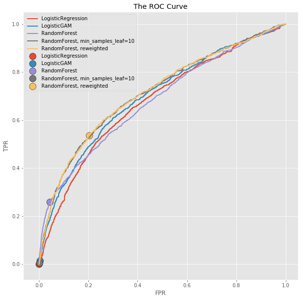

```python
roc_curves = [logit_roc, gam_roc] + rdf_roc_curves
roc_locations = [logit_loc, gam_loc] + rdf_roc_locs

fig, ax = plt.subplots(1,1, figsize=(10,10))
for i, roc in enumerate(roc_curves):
    fpr, tpr = roc
    fpr_clf, tpr_clf = roc_locations[i]
    index = table[i][0]
    ax.plot(fpr, tpr, linewidth=2, label=index)
    ax.scatter(fpr_clf, tpr_clf, edgecolors='black',
               s=180, label=index)
ax.update({'xlabel':'FPR', 'ylabel':'TPR',
           'title':'The ROC Curve'})
_ = ax.legend()
```

## Comments

### Question (d)

- The ROC curve itself generally does not change much, but the point on ROC curve that corresponds to the classifer shifted from left-bottom corner to the middle part of the curve dramatically after we adjusted the class weights.
- This is due to the change of loss function that leads to a change of classification threshold, as we discussed in last mini. Essentially, adding more weights to the rare class "1" is equivalent to rising the False Negative Loss. For example: if the weights of class "1" samples is doubled, we will make 2 errors if predicting "0" for a true "1" instead of 1 error. Increasing FN loss leads to higher sensitivity (which is almost 0 previously) and lower specificity (which is almost 1 previously). Therefore, the new trade-off moves the classifier upward.
- The misclassification rate of the rebalanced Random Forest is higher than the other models. This is natural because misclassification rate corresponds to 0-1 loss, which is no longer the optimization objective of the classifier. However, if we look at the confusion matrix, the FPs and FNs become more balanced.

```python
print(confusion_matrix(
    y_valid, rdf_clfs[1][1].predict(X_valid)))
print(confusion_matrix(
    y_valid, rdf_clfs[2][1].predict(X_valid)))
```

```
[[8006    8]
 [1022    6]]
[[6378 1636]
 [ 477  551]]
```

## Features Importance Plot

```python
def importance_plot(clf, ax, X, X_names):
    importances = clf.feature_importances_
    indices = np.argsort(importances)
    if type(clf) is RandomForestClassifier:
        std = np.std([tree.feature_importances_
                      for tree in clf.estimators_], axis=0)
        ax.barh(range(X.shape[1]),
                importances[indices],
                yerr=std[indices], align="center")
    else:
        ax.barh(range(X.shape[1]),
                importances[indices],
                align="center")
    ax.set_yticks(range(len(indices)))
    ax.set_yticklabels(X_names[indices])
    ax.update({'xlabel':'Relative Importance',
               'ylabel':'Feature',
               'title':'Feature Importances Plot'})
    return ax
```

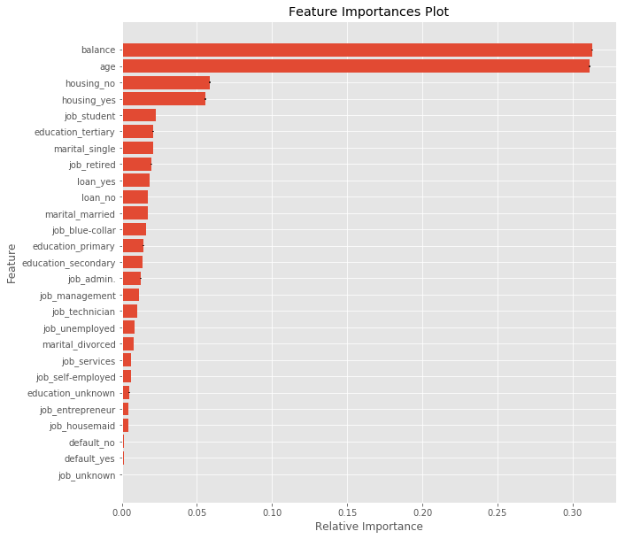

```python
fig, ax = plt.subplots(1,1, figsize=(10,10))
ax = importance_plot(rdf_clfs[1][1], ax, X, X_names)
```

## Partial Dependence Plot

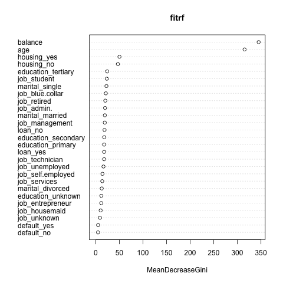

```python
%%R -i X_train -i X_test -i y_train -i y_test
options(warn = -1)
library(randomForest)
fitrf = randomForest(
    X_train, as.factor(y_train),
    ntree=500, nodesize=10)
varImpPlot(fitrf)
```

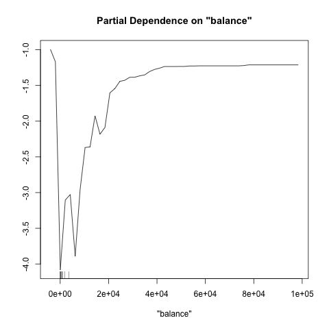

```python
%%R
partialPlot(fitrf, X_train, x.var='balance', which.class=1)
```

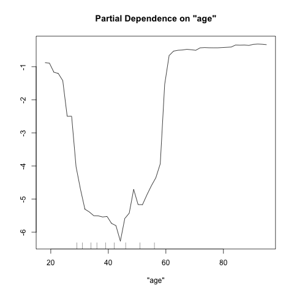

```python
%%R
partialPlot(fitrf, X_train, x.var='age', which.class=1)
```

# AdaBoost

```python
def get_circle_data(n):
    gaussian_2d = scipy.stats.multivariate_normal(
        mean = np.zeros(2), cov = np.eye(2))
    X = gaussian_2d.rvs(n)
    Y = np.where(X[:,0]**2+X[:,1]**2<1, 1, -1)
    return(X,Y)

def find_split(X, y, wgts=None):
    n = X.shape[0]
    dtc = DecisionTreeClassifier(max_depth=1)
    fit = dtc.fit(X,y, sample_weight=wgts)
    tree_info = {
        'variable_idx' : fit.tree_.feature[0],
        'threshold' : fit.tree_.threshold[0],
        'guess_less' : np.argmax(fit.tree_.value[1])*2-1,
        'guess_greater' : np.argmax(fit.tree_.value[2])*2-1
    }
    return(fit, tree_info)

def draw_boosted_trees(trees, X, score=None,fsize=10):
    fig, ax = plt.subplots(1,1, figsize=(fsize,fsize))
    if score is not None:
        ax.scatter(X[:,0], X[:,1], c=score, cmap=plt.get_cmap('plasma'))
    else:
        ax.scatter(X[:,0], X[:,1])
    line_col='grey'
    for fit in trees:
        variable_idx = fit.tree_.feature[0]
        threshold = fit.tree_.threshold[0]
        if variable_idx==0:
            ax.axvline(x = threshold, color=line_col)
        else:
            ax.axhline(y = threshold, color=line_col)
    ax.update({'xlabel':'X1',
           'ylabel':'X2',
           'title':'Circle Data'})
    return fig, ax
```

```python
def my_adaboost(X, y, B=10):
    n = X.shape[0]
    wgts = np.repeat(1/n, n)
    trees = []#To store your trees.  Use append()
    alphas = np.zeros(B)#To store your alphas
    bar = ProgressBar()
    for i, b in enumerate(bar(range(B))):
        tree, info = find_split(X, y, wgts)
        y_hat = tree.predict(X)
        err = wgts.dot(y_hat!=y)/np.sum(wgts)

        alphas[b] = np.log((1-err)/err)
        trees.append(tree)
        wgts = wgts * np.exp(alphas[b]*(y_hat!=y))
    return(trees, alphas)

def predict_ada(trees, alphas, X, y=None):
    n = X.shape[0]
    score = np.zeros(n)
    B = len(trees)
    test_err = np.zeros(B)
    for b in range(B):
        #Update your score to include the contribution from tree b
        score += alphas[b]*trees[b].predict(X)
        preds = np.sign(score)
        if y is not None:
            test_err[b] = 1-accuracy_score(
                y, preds, normalize=1)
    if y is None:
        return(score, preds)
    return(score, preds, test_err)

def calculate_partial_dependence_x1(trees, alphas, X):
    m = 50#Number of grid points to evaluate partial dependence
    x = np.linspace(np.min(X[:,0]), np.max(X[:,0]), m)
    pdep = np.zeros(m)
    fake = X.copy()
    for i in range(m):
        fake[:,0] = x[i]
        score, preds = predict_ada(trees, alphas, fake)
        pdep[i] = np.mean(np.where(score>0,1,0))
    return(x, pdep)
```

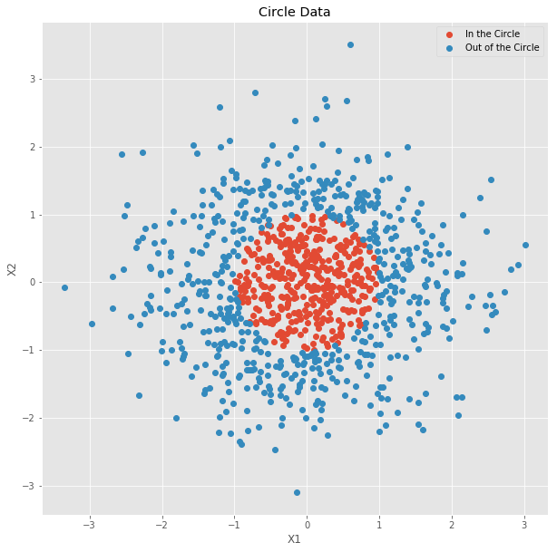

```python
# view the simulated circle data
X, y = get_circle_data(1000)
X_train, X_test, y_train, y_test = train_test_split(
    X, y, test_size=0.5, random_state=1)
fig, ax = plt.subplots(1,1, figsize=(10,10))
ax.plot(X[y==1][:,0], X[y==1][:,1],
        'o', label='In the Circle')
ax.plot(X[y==-1][:,0], X[y==-1][:,1],
        'o', label='Out of the Circle')
ax.update({'xlabel':'X1',
           'ylabel':'X2',
           'title':'Circle Data'})
_ = ax.legend()
```

```
100% (1 of 1) |###########################| Elapsed Time: 0:00:00 Time: 0:00:00
100% (2 of 2) |###########################| Elapsed Time: 0:00:00 Time: 0:00:00
100% (3 of 3) |###########################| Elapsed Time: 0:00:00 Time: 0:00:00
100% (6 of 6) |###########################| Elapsed Time: 0:00:00 Time: 0:00:00
```

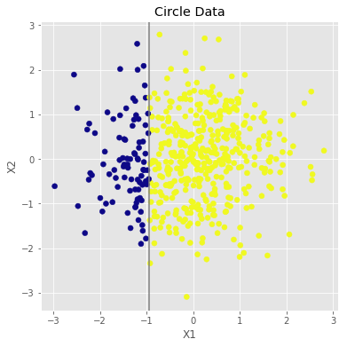

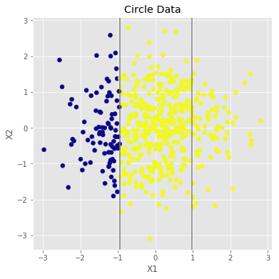

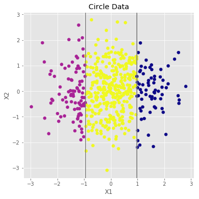

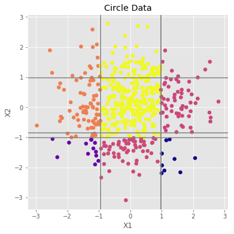

```python
for b in [1,2,3,6]:
    trees, alphas = my_adaboost(X_train, y_train, B=b)
    score, preds, test_err = predict_ada(trees, alphas, X_test, y_test)
    fig, ax = draw_boosted_trees(trees, X_test, score, fsize=6)
```

## Many Trees

```
100% (250 of 250) |#######################| Elapsed Time: 0:00:00 Time: 0:00:00
```

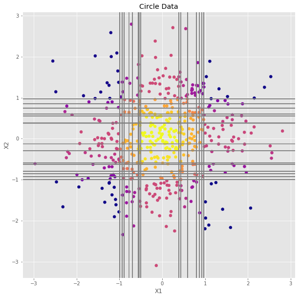

```python
trees, alphas = my_adaboost(X_train, y_train, B=250)
score, preds, train_err = predict_ada(trees, alphas, X_train, y_train)
score, preds, test_err = predict_ada(trees, alphas, X_test, y_test)
fig, ax = draw_boosted_trees(trees, X_test, score)
```

## Training and Test Error

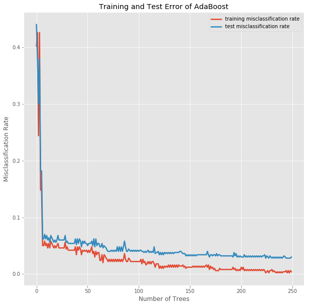

```python
fig, ax = plt.subplots(1,1, figsize=(10,10))
ax.plot(train_err, linewidth=2.5,
        label='training misclassification rate')
ax.plot(test_err, linewidth=2.5,
        label='test misclassification rate')
ax.update({'xlabel':'Number of Trees',
           'ylabel':'Misclassification Rate',
           'title':'Training and Test Error of AdaBoost'})
_ = ax.legend()
```

## Partial Dependence Plot

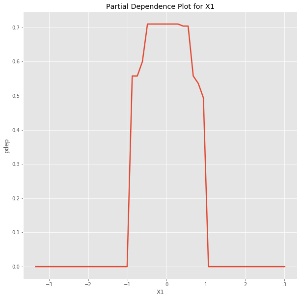

```python
x, pdep = calculate_partial_dependence_x1(
    trees, alphas, X_train)
fig, ax = plt.subplots(1,1, figsize=(10,10))
ax.plot(x, pdep, linewidth=2.5)
_ = ax.update({'xlabel':'X1', 'ylabel':'pdep',
               'title':'Partial Dependence Plot for X1'})
```

# Gradient Boosting

```python
# cast matrices
d_train = xgb.DMatrix(X_train.values, label=y_train)
d_valid = xgb.DMatrix(X_valid.values, label=y_valid)
d_test = xgb.DMatrix(X_test.values, label=y_test)
```

## Untuned XGB

```python
xgb_param = {
    'objective':'binary:logistic',
    'eval_metric': 'auc',
    'seed': 1,
}

xgb_clf = xgb.train(
    xgb_param, d_train, num_boost_round=100)
# make prediction
prob_pred = xgb_clf.predict(d_valid)
y_pred = (prob_pred > 0.5).astype(int)

xgb_summary, xgb_roc, xgb_loc = metrics_bundle(
    'XGBoost, untuned',
    None, y_valid, y_pred, prob_pred)
table.append(xgb_summary)
print(tabulate(table, headers=[
    'clf', 'misclf rate', 'oob error',
    'auc', 'top1k success']))
```

```
clf                                  misclf rate    oob error       auc    top1k success
---------------------------------  -------------  -----------  --------  ---------------
LogisticRegression                      0.113802   nan         0.674543            0.261
LogisticGAM                             0.114576   nan         0.695845            0.313
RandomForest                            0.122871     0.129286  0.678699            0.326
RandomForest, min_samples_leaf=10       0.113913     0.117636  0.712334            0.343
RandomForest, reweighted                0.233687     0.237595  0.712847            0.344
XGBoost, untuned                        0.11347    nan         0.69684             0.331
```

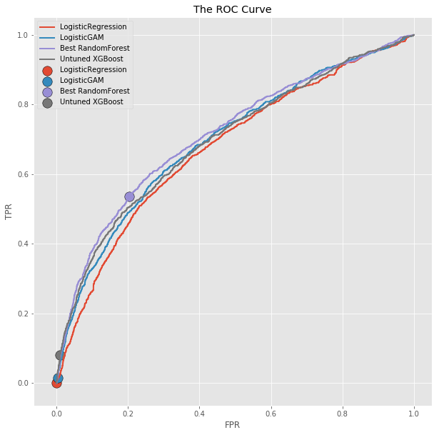

```python
def compare_roc(xgb_roc, xgb_loc, label='XGBoost'):
    roc_curves = [logit_roc, gam_roc, rdf_roc_curves[2], xgb_roc]
    roc_locations = [logit_loc, gam_loc, rdf_roc_locs[2], xgb_loc]
    roc_labels = ['LogisticRegression', 'LogisticGAM',
                  'Best RandomForest', label]

    fig, ax = plt.subplots(1,1, figsize=(10,10))
    for i, roc in enumerate(roc_curves):
        fpr, tpr = roc
        fpr_clf, tpr_clf = roc_locations[i]
        index = roc_labels[i]
        ax.plot(fpr, tpr, linewidth=2, label=index)
        ax.scatter(fpr_clf, tpr_clf, edgecolors='black',
                   s=180, label=index)
    ax.update({'xlabel':'FPR', 'ylabel':'TPR',
               'title':'The ROC Curve'})
    _ = ax.legend()
    return fig, ax
fig, ax = compare_roc(xgb_roc, xgb_loc, 'Untuned XGBoost')
```

## Tuning XGBoost

```python
cv_params = {
    'objective':'binary:logistic',
    'eval_metric': 'auc',
    'seed': 42,
    'eta': 0.1
}
cv = xgb.cv(cv_params, d_train, num_boost_round=500)
print("num_boost_round with best test-auc:",
      np.argmax(cv['test-auc-mean'])+1)
```

```
num_boost_round with best test-auc: 40
```

```
clf                                  misclf rate    oob error       auc    top1k success
---------------------------------  -------------  -----------  --------  ---------------
LogisticRegression                      0.113802   nan         0.674543            0.261
LogisticGAM                             0.114576   nan         0.695845            0.313
RandomForest                            0.122871     0.129286  0.678699            0.326
RandomForest, min_samples_leaf=10       0.113913     0.117636  0.712334            0.343
RandomForest, reweighted                0.233687     0.237595  0.712847            0.344
XGBoost, untuned                        0.11347    nan         0.69684             0.331
XGBoost, eta=0.1                        0.114355   nan         0.699561            0.327
```

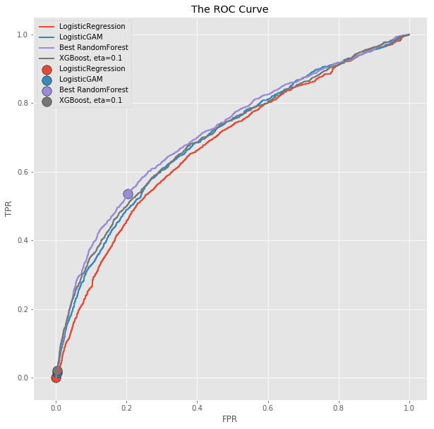

```python
# eta = 0.1
xgb_param = {
    'objective':'binary:logistic',
    'eval_metric': 'auc',
    'seed': 42,
    'eta': 0.1
}

xgb_clf = xgb.train(
    xgb_param, d_train,
    num_boost_round=np.argmax(cv['test-auc-mean'])+1)
# make prediction
prob_pred = xgb_clf.predict(d_valid)
y_pred = (prob_pred > 0.5).astype(int)

xgb_summary, xgb_roc, xgb_loc = metrics_bundle(
    'XGBoost, eta=0.1',
    None, y_valid, y_pred, prob_pred)
table.append(xgb_summary)
print(tabulate(table, headers=[
    'clf', 'misclf rate', 'oob error',
    'auc', 'top1k success']))
fig, ax = compare_roc(xgb_roc, xgb_loc, 'XGBoost, eta=0.1')
```

- AUC was increased by a little bit.

## Tune max_depth and scale_pos_weight

```python
xgb_clf = XGBClassifier()
param_grid = {
    'objective': ['binary:logistic'],
    'random_state': [42],
    'n_estimators': [40],
    'learning_rate': [0.1],
    'max_depth': [2, 4, 8, 12],
    'scale_pos_weight': [0.3, 1, 3],
    'gamma': [0],
    'subsample': [1.0],
    'min_child_weight': [1]
}
kfold = StratifiedKFold(
    n_splits=5, shuffle=True, random_state=1)
gscv = GridSearchCV(
    xgb_clf, param_grid, scoring='roc_auc',
    n_jobs=-1, cv=kfold, verbose=0)
gs_result = gscv.fit(X_train, y_train)
```

```
{'gamma': 0, 'learning_rate': 0.1, 'max_depth': 8, 'min_child_weight': 1, 'n_estimators': 40, 'objective': 'binary:logistic', 'random_state': 42, 'scale_pos_weight': 1, 'subsample': 1.0}
clf                                  misclf rate    oob error       auc    top1k success
---------------------------------  -------------  -----------  --------  ---------------
LogisticRegression                      0.113802   nan         0.674543            0.261
LogisticGAM                             0.114576   nan         0.695845            0.313
RandomForest                            0.122871     0.129286  0.678699            0.326
RandomForest, min_samples_leaf=10       0.113913     0.117636  0.712334            0.343
RandomForest, reweighted                0.233687     0.237595  0.712847            0.344
XGBoost, untuned                        0.11347    nan         0.69684             0.331
XGBoost, eta=0.1                        0.114355   nan         0.699561            0.327
XGBoost, tuned                          0.113249   nan         0.701483            0.33
```

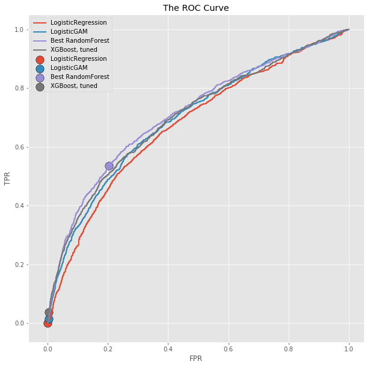

```python
print(gs_result.best_params_)

# fit the model with the best_params
xgb_tuned = XGBClassifier()
for key, val in gs_result.best_params_.items():
    setattr(xgb_tuned, key, val)
xgb_tuned.fit(X_train, y_train)

# evaluation
y_pred = xgb_tuned.predict(X_valid)
prob_pred = xgb_tuned.predict_proba(X_valid)[:,1]

xgb_summary, xgb_roc, xgb_loc = metrics_bundle(
    'XGBoost, tuned',
    None, y_valid, y_pred, prob_pred)
table.append(xgb_summary)
print(tabulate(table, headers=[
    'clf', 'misclf rate', 'oob error',
    'auc', 'top1k success']))
fig, ax = compare_roc(xgb_roc, xgb_loc, 'XGBoost, tuned')
```

- We can see that AUC was again increased by little bit.

## Freestyle Tuning: AUC

```python
def fit_and_compare(clfs, X_train, y_train,
                    X_test, y_test,
                    refit='all', silent=[]):
    table = []
    fig, ax = plt.subplots(1,1, figsize=(10,10))
    for i, (name, clf) in enumerate(clfs):
        if i in silent: continue
        if refit=='all' or i in refit:
            print("Fitting", name+'...')
            clf.fit(X_train, y_train)
        else:
            print("Using fitted", name+'...')
        y_pred = clf.predict(X_test)
        if type(clf) is LogisticGAM:
            prob_pred = clf.predict_proba(X_test)
        else:
            prob_pred = clf.predict_proba(X_test)[:,1]
        summary, roc, roc_loc = metrics_bundle(
            name, clf, y_test, y_pred, prob_pred)
        fpr, tpr = roc
        fpr_clf, tpr_clf = roc_loc
        ax.plot(fpr, tpr, linewidth=2, label=name)
        ax.scatter(fpr_clf, tpr_clf, edgecolors='black',
               s=180, label=name)
        table.append(summary)
    table = tabulate(table, headers=[
        'clf', 'misclf rate', 'oob error', 'auc', 'top1k success'])
    ax.update({'xlabel':'FPR', 'ylabel':'TPR',
           'title':'The ROC Curve'})
    _ = ax.legend()
    return table, fig, ax
```

```python
# task 1, aiming for high AUC
xgb_clf = XGBClassifier()
param_grid = {
    'objective': ['binary:logistic'],
    'random_state': [1],
    'n_estimators': [50],
    'learning_rate': [0.1],
    'max_depth': [8],
    'scale_pos_weight': [3],
    'gamma': [0, 1, 2, 5],
    'subsample': [0.9, 1],
    'min_child_weight': [1, 3, 5]
    'reg_lambda': [0.5, 1, 5]
}
kfold = StratifiedKFold(
    n_splits=5, shuffle=True, random_state=1)
gscv = GridSearchCV(
    xgb_clf, param_grid,
    scoring='roc_auc',
    n_jobs=-1, cv=kfold, verbose=2)
gs_result = gscv.fit(X_train, y_train)
# the cross-validation process was too long,
# hence left out. After some effort, we choose
# the following parameters
```

```python
clfs = [
    ('LogisticRegression', LogisticRegression(C=10e5)),
    ('LogisticGAM', LogisticGAM()),
    ('RandomForest, rebalanced',
     RandomForestClassifier(
        min_samples_leaf=10, class_weight='balanced',
        n_estimators=500, oob_score=True, n_jobs=-1,
        random_state=1)),
    ('XGBoost (AUC)', XGBClassifier(
        n_estimators=55, scale_pos_weight=2.9,
        max_depth=8, gamma=1.8, learning_rate=0.1,
        subsample=1, reg_lambda=1.05
    ))
]
```

```
Fitting LogisticRegression...
Fitting LogisticGAM...
Fitting RandomForest, rebalanced...
Fitting XGBoost (AUC)...
clf                         misclf rate    oob error       auc    top1k success
------------------------  -------------  -----------  --------  ---------------
LogisticRegression             0.113802   nan         0.674543            0.261
LogisticGAM                    0.114576   nan         0.695845            0.313
RandomForest, rebalanced       0.233687     0.237595  0.712847            0.344
XGBoost (AUC)                  0.129286   nan         0.703179            0.341
```

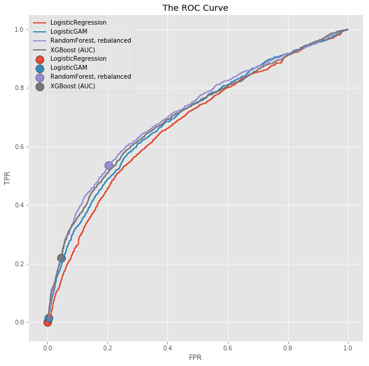

```python
%%capture --no-stdout --no-display
table, fig, ax = fit_and_compare(
    clfs, X_train, y_train,
    X_valid, y_valid)
print(table)
```

- The AUC of XGBoost Classifier on validation set is 0.703179. Which is still lower than that of the RandomForest, 0.712847.
- They are fairly close nevertheless.
- The XGBoost Classifier failed to beat the Random Forest in terms of AUC.

## Freestyle Tuning: Top 1000 Success Rate

```python
# task 2, aiming for high Top 1000 Success rate
# We made a customized score to let the
# GridSearchCV optimize
def top1k_success_rate(y_true, y_pred):
    p_pred = y_pred[:, 1]
    top1k_indices = np.argsort(-p_pred)[:1000]
    return sum(y_true[list(top1k_indices)])/1000

success_rate_scorer = make_scorer(
    top1k_success_rate, needs_proba=True,
    greater_is_better=True)

xgb_clf = XGBClassifier()
param_grid = {
    'objective': ['binary:logistic'],
    'random_state': [1],
    'n_estimators': [100],
    'learning_rate': [0.05, 0.1],
    'max_depth': [8, 10, 12, 14],
    'scale_pos_weight': [1, 3, 5],
    'gamma': [0, 1, 3, 5],
    'subsample': [0.8, 0.9, 1],
    'min_child_weight': [1, 3]
}
kfold = StratifiedKFold(
    n_splits=5, shuffle=True, random_state=1)
gscv = GridSearchCV(
    xgb_clf, param_grid,
    scoring=success_rate_scorer,
    n_jobs=-1, cv=kfold, verbose=2)
gs_result = gscv.fit(X_train, y_train)
# the cross-validation process was too long,
# hence left out. After some effort, we choose
# the following parameters
```

```python
clfs = [
    ('LogisticRegression', LogisticRegression(C=10e5)),
    ('LogisticGAM', LogisticGAM()),
    ('RandomForest, rebalanced',
     RandomForestClassifier(
        min_samples_leaf=10, class_weight='balanced',
        n_estimators=500, oob_score=True, n_jobs=-1,
        random_state=1)),
    ('XGBoost (Success rate)', XGBClassifier(
        n_estimators=220, scale_pos_weight=5,
        max_depth=14, gamma=3, learning_rate=0.05,
        subsample=0.9, reg_lambda=1, random_state=1,
        min_child_weight=1
    ))
]
```

```
Fitting LogisticRegression...
Fitting LogisticGAM...
Fitting RandomForest, rebalanced...
Fitting XGBoost (Success rate)...
clf                         misclf rate    oob error       auc    top1k success
------------------------  -------------  -----------  --------  ---------------
LogisticRegression             0.113802   nan         0.674543            0.261
LogisticGAM                    0.114576   nan         0.695845            0.313
RandomForest, rebalanced       0.233687     0.237595  0.712847            0.344
XGBoost (Success rate)         0.155939   nan         0.695552            0.358
```

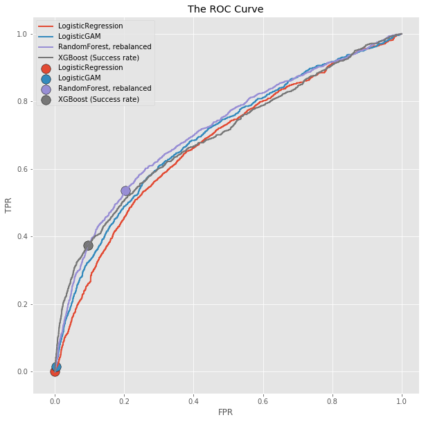

```python
%%capture --no-stdout --no-display
# comparison on the validation set
table, fig, ax = fit_and_compare(
    clfs, X_train, y_train,
    X_valid, y_valid)
print(table)
```

- For this task, the XGBoost Classifer beats the Random Forest in terms of the top 1000 clients success rate in a significant way.
- The success rate was improved from 0.344 to 0.358.
- Interestingly, the XGBoost model we end up using for this task is very different from that optimizes AUC: almost all parameters are different.
- We can conclude that the XGBoost Classifer can do better on the top 1000 clients success rate than the Random Forest Classifier.

## The Special Holdout Test Set

```python
clfs = [
    ('LogisticRegression', LogisticRegression(C=10e5)),
    ('LogisticGAM', LogisticGAM()),
    ('RandomForest, rebalanced',
     RandomForestClassifier(
        min_samples_leaf=10, class_weight='balanced',
        n_estimators=500, oob_score=True, n_jobs=-1,
        random_state=1)),
    ('XGBoost (AUC)', XGBClassifier(
        n_estimators=55, scale_pos_weight=2.9,
        max_depth=8, gamma=1.8, learning_rate=0.1,
        subsample=1, reg_lambda=1.05
    )),
    ('XGBoost (Success rate)', XGBClassifier(
        n_estimators=220, scale_pos_weight=5,
        max_depth=14, gamma=3, learning_rate=0.05,
        subsample=0.9, reg_lambda=1, random_state=1,
        min_child_weight=1
    ))
]
```

```
Fitting LogisticRegression...
Fitting LogisticGAM...
Fitting RandomForest, rebalanced...
Fitting XGBoost (AUC)...
Fitting XGBoost (Success rate)...
clf                         misclf rate    oob error       auc    top1k success
------------------------  -------------  -----------  --------  ---------------
LogisticRegression             0.118766   nan         0.656059            0.262
LogisticGAM                    0.118987   nan         0.68213             0.311
RandomForest, rebalanced       0.230123     0.237595  0.70643             0.338
XGBoost (AUC)                  0.132257   nan         0.70095             0.341
XGBoost (Success rate)         0.154484   nan         0.698691            0.361
```

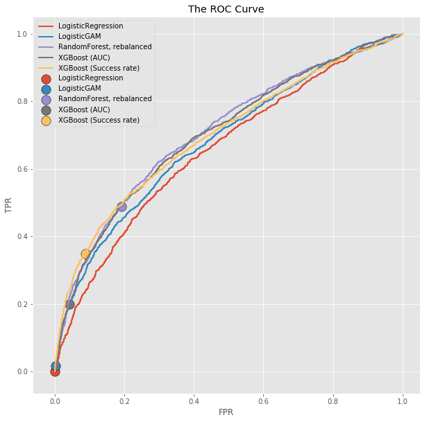

```python
%%capture --no-stdout --no-display
# final comparison on the special holdout set
table, fig, ax = fit_and_compare(
    clfs, X_train, y_train,
    X_test, y_test)
print(table)
```

- On the special holdout test set, the XGBoost (AUC) Classifier obtained 0.70095 in AUC score, which is closer to that of the RandomForest (0.70643).
- For the other task, the XGBoost (Success rate) Classifer achieved 0.361 in top 1000 clients success rate, which significantly beats the RandomForest (0.338). We can conclude that the improvement in this metric is generalized to an unseen data set.
- After all the tuning efforts, we are able to beat random forests in terms of the top 1000 clients success rate. And we are close to random forest on AUC.

## Variable Importance Plot

```python
xgb_auc_clf = clfs[-2][1]
xgb_top1k_clf = clfs[-1][1]
```

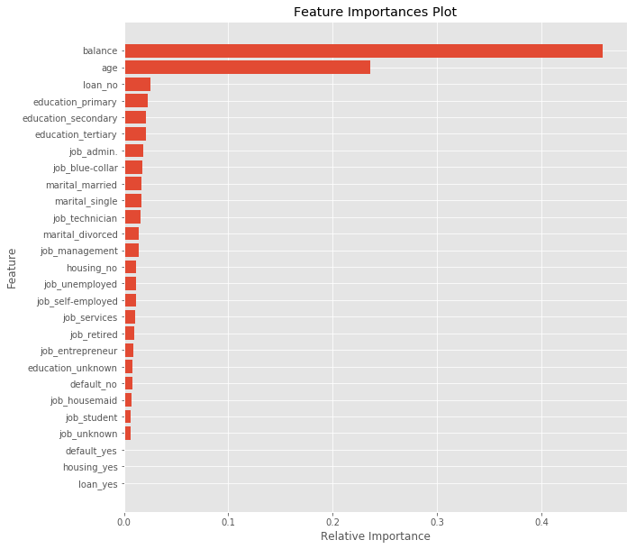

```python
# XGBoost (AUC)
fig, ax = plt.subplots(1,1, figsize=(10,10))
ax = importance_plot(xgb_auc_clf, ax, X, X_names)
```

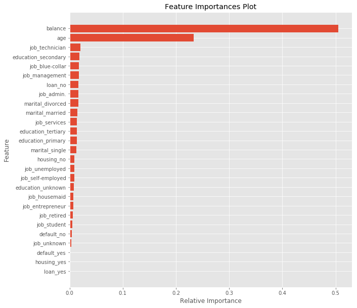

```python
# XGBoost (Success Rate)
fig, ax = plt.subplots(1,1, figsize=(10,10))
ax = importance_plot(xgb_top1k_clf, ax, X, X_names)
```